# HW1_S23

Nicole Higgins

2023-01-26

## Homework 1

### Q0: Names

Who did you work with on this assignment? You’ll get a bonus 5 points if you name someone and they name you. *No scores above 100% are allowed, but these bonus points can repair mistakes on this assignment*.

**I worked with Jonny :)**

### Q1: Eigenvalues of a symmetric matrix

- Suppose that $A$ is an $n\times n$ matrix and that $x$ is a vector in $\mathbb{R}^n$. Is $x^TAx$ a number, vector, or matrix?

**it is a number, since the dimensions [1 x n][n x n][n x 1] = [1 x 1]**

- Suppose that $Ax = \lambda x$ and $A = A^T$ and $x$ is not all zeros; that is, $\lambda$ is an eigenvector of a symmetric matrix $A$ with eigenvalue $\lambda$. Show that $x^TAx = \lambda x^Tx$. Explain why this means that $\lambda$ must be a real number.

**Given $Ax = \lambda x$, then $x^TAx = x^T\lambda x$. Since $\lambda$ is a scalar, $x^T\lambda x = \lambda x^Tx$. Solving for $\lambda$, we get $\lambda = x^TAx/x^Tx$. Given that $x$ is not all zeros, we know $x^T$ is also not all zeros. Thus, $x^Tx$ is nonzero so $\lambda$ is real.**

- Form the matrices $P$ and $S$ in R and use the syntax *eigen(A)$values* to find their eigenvalues. (According to the result we proved, $S$ should have real eigenvalues and $P$ might or might not have real eigenvalues).
  $$P =
  \begin{pmatrix} -4&5&6\\1&0&9
  \\9&1&2\end{pmatrix}
  \qquad
  S = \begin{pmatrix}
  -1&2&1\\2&7&-3\\1&-3&4\end{pmatrix}$$

```r
pData = c(-4,1,9,5,0,1,6,9,2)
sData = c(-1,2,1,2,7,-3,1,-3,4)

P = matrix(pData, 3, 3)
S = matrix(sData, 3, 3)

print(P)
```

```
##      [,1] [,2] [,3]
## [1,]   -4    5    6
## [2,]    1    0    9
## [3,]    9    1    2
```

```r
print(S)
```

```
##      [,1] [,2] [,3]
## [1,]   -1    2    1
## [2,]    2    7   -3
## [3,]    1   -3    4
```

```r
eigen(P)$values
```

```
## [1]  9.988620673572962+0.00000000000000i -5.994310336786480+2.79607365674972i
## [3] -5.994310336786480-2.79607365674972i
```

```r
eigen(S)$values
```

```
## [1]  8.999999999999998  3.000000000000006 -1.999999999999996
```

### Q2: Nearly R-O

Write some code to create and print out this matrix (it’s possible to do it in two lines, but any solution is fine as long as you don’t separately type all 16 entries). Explain why it is nearly a R-O matrix, where “R-O” stands for something on our first-day slides.
$$A = \begin{pmatrix}
1&3&5&10\\
10&30&50&100\\
-2&-6&-10&-20\\
100&300&4&4
\end{pmatrix}$$

```r
A <- c(1, 10, -2, 100) %*% t(c(1, 3, 5, 10))
A[4,3:4] <- 4

print(A)
```

```
##      [,1] [,2] [,3] [,4]
## [1,]    1    3    5   10
## [2,]   10   30   50  100
## [3,]   -2   -6  -10  -20
## [4,]  100  300    4    4
```

### Q3: Basic graph example

Write some code to plot the quadratic function $y=x^2 - 5x + 2$. Make sure that the minimum is visible inside your figure.

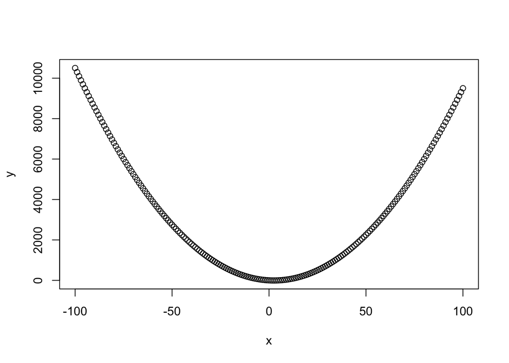

```r
x = -100:100
y = x^2 - 5*x + 2

plot(x,y)
```

### Q4: When power functions look linear

Consider the three graphs that the following code produces. *Note: I don’t need to see the graphs in the version you turn in. Please put “echo=FALSE” on line 60 once you finish looking at the graphs.*

Comment carefully on the differences you see between the three versions. Then explain why a function of the form $y = x^p$ looks linear on a log-log plot. *Hint: let $w = \log_{10}(y)$ and let $t = \log_{10}(x)$, then show that there is a linear relationship between $t$ and $w$.*

**The first plot is on traditionally scaled axes - that is, x and y increment by one each tick - and the resulting graph is nearly flat and difficult to interpret. The second plot scales the axes as logarithmic, while the third plot assumes a logarithmic relationship.**

**The relationship is linear on the second two plots because log(y) = log(x^-2) = -2log(x) by change of base so we see y = -2x when the plot is on a log scale.**

### Q5: Create a letter

As on the Day 1 activity, create a color image showing the first letter of your name by building appropriate matrices in R. Give it a white background (initialize the matrices with 1’s instead of 0’s). Add it to the Google Doc, and also include it here.

```r
library('magick')
```

```
## # A tibble: 1 × 7
##   format width height colorspace matte filesize density
##   <chr>  <int>  <int> <chr>      <lgl>    <int> <chr>
## 1 PNG      500    500 sRGB       FALSE        0 72x72
```

[figure not shown]

```r
nRed <- matrix(1,500,500) # a 500x500 grid of zeros for each color
nGreen <- matrix(1,500,500)
nBlue <- matrix(1,500,500)

for (i in 1:500){
  for (j in 1:500){
    if ((44<j & j<111) | (389<j & j<455) | (abs(j - i) < 62)){
      nRed[i,j] <- 0.6
      nBlue[i,j] <- 0.9
      nGreen[i,j] <- 0.5
      if (abs(j - i) < 27){
        nRed[i,j] <- 0.7
        nBlue[i,j] <- 1
        nGreen[i,j] <- 0.6
      }
    }
  }
}

nData <- array(c(nRed,nGreen,nBlue),dim = c(500,500,3))

nic <- image_read(nData)
print(nic) # this displays the image in RStudio and knitted documents
```

### Q6: High contrast image

The image “Department.png” is a cropped version of a photo by Stefani Reynolds in a January 2023 article about the upcoming US debt ceiling crisis in the New York Times. It shows part of the Treasury Department building in Washington. It is a color image, but it looks pretty gray because for most pixels, the values in the R, G, and B channels are all close together. Save the image in the same folder as your main RMD file and then uncomment these lines to see it:

```
## # A tibble: 1 × 7
##   format width height colorspace matte filesize density
##   <chr>  <int>  <int> <chr>      <lgl>    <int> <chr>
## 1 PNG      370    382 sRGB       FALSE   247388 57x57
```

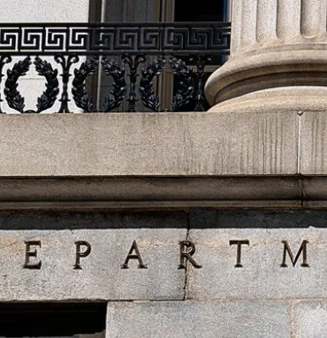

```r
library("magick")
a = image_read("Department.png")
A = as.integer(a[[1]])/256
redA = A[,,1]
greenA = A[,,2]
blueA = A[,,3]
print(a) # this displays the image in RStudio and knitted documents
```

We will make a high-contrast version of this image using a new code trick: updating a matrix or vector using conditional tests.

Here is a first example where we create a vector and then ask which entries are less than 5:

```r
v <- 1:8
print(v)
```

```
## [1] 1 2 3 4 5 6 7 8
```

```r
print(v < 5)
```

```
## [1]  TRUE  TRUE  TRUE  TRUE FALSE FALSE FALSE FALSE
```

The useful trick is that you can update the entries for which the condition is true:

```r
v[v<5] <- -1
print(v)
```

```
## [1] -1 -1 -1 -1  5  6  7  8
```

The same trick works for matrices and high-dimensional arrays:

```r
a <- matrix(rnorm(12),3,4) # create a 3x4 matrix with normally distributed entries
a[a<0] <- 0 # set all negative elements to be zero
print(a) # we should see about half zeros, half positive numbers
```

```
##                    [,1]              [,2]               [,3]               [,4]
## [1,] 0.9559354603525571 0.000000000000000 1.2126636755495721 0.0000000000000000
## [2,] 0.0000000000000000 1.056449530968652 0.2746390630851875 0.8350563731938689
## [3,] 1.0722330963798103 0.000000000000000 0.1939095187800516 0.4017037703975923
```

The three matrices redA, greenA, and blueA contain numbers between 0 and 1. Pick a cutoff between 0 and 1 (0.5 is a good choice but you can experiment) and then set all entries to 1 if they’re greater than the cutoff, or 0 otherwise. Then display the altered image, the “high contrast” version. It should be mostly black-and-white but there will be some colored pixels - explain why.

```
## # A tibble: 1 × 7
##   format width height colorspace matte filesize density
##   <chr>  <int>  <int> <chr>      <lgl>    <int> <chr>
## 1 PNG      370    382 sRGB       FALSE        0 72x72
```

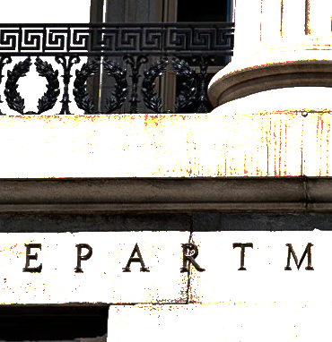

```r
redA[redA>0.5] <- 1
greenA[greenA>0.5] <-1
blueA[blueA>0.5] <- 1

newA <- array(c(redA,greenA,blueA), dim = c(382,370,3))

highCon <- image_read(newA)

print(highCon)
```

**The resulting image has some colored pixels because the cutoff might make some mid-tones as fully one color or another. For example, if a pixel has rgb values (0.6, 0.1, 0), the red value will increase to 1 and the pixel will appear red.**